# S2_MGF Figure 2: Alpha Diversity

Stephen Formel

12/3/2020

### S2_MG Manuscript: Figure 2 - alpha diversity

Last updated 3 Dec 2020 by Steve Formel

Description: What does alpha diversity look like? How many samples are necessary to legitimately describe salt marsh soil microbial communities?

### load libraries

```r
library(cowplot)
library(tidyverse)
library(iNEXT)
library(Rmisc)
```

### Load and Clean data

```r
source("./S2_MGF_load_packages_and_clean_data.R")
```

### Traditional alpha diversity approach

This is a more traditional approach of estimating alpha diversity. Abundance weighted diversity is calculated for each sample and then summary statistics are calculated for the site and time point.

```r
p <- plot_richness(fung.2season_with_outliers)

#convert value to Hill numbers

p1 <- p$data
p1$value[which(p1$variable == "Observed")] <- p1$value[which(p1$variable == "Observed")]
p1$value[which(p1$variable == "Shannon")] <- exp(p1$value[which(p1$variable == "Shannon")])
p1$value[which(p1$variable == "Simpson")] <- 1/(1 - p1$value[which(p1$variable == "Simpson")])

p1$hill_order <- NA

p1$hill_order[which(p1$variable == "Observed")] <- 0
p1$hill_order[which(p1$variable == "Shannon")] <- 1
p1$hill_order[which(p1$variable == "Simpson")] <- 2

#rename levels for site
p1$site <- as.factor(p1$site)
levels(p1$site) <- plyr:::revalue(levels(p1$site), c("BJ" = "Heavily Oiled", "F" = "Lightly Oiled"))

p1$season <- factor(p1$season, levels = c("WINTER", "SUMMER"))
p1$season <- plyr:::revalue(p1$season, replace = c("WINTER" = "Winter", "SUMMER" = "Summer"))

p1.summary <- summarySE(data = p1,
                        measurevar = "value",
                        groupvars = c("site", "season", "hill_order"))
```

### Plot Traditional alpha diversity

This is figure 2A

```r
avg.abund.plot <- p1.summary %>%
  filter(hill_order %in% c(0,2)) %>%
  ggplot(aes(x = site,
           y = value,
           shape = factor(hill_order))) +
  facet_wrap(~ season) +
  geom_errorbar(aes(ymax = value + ci,
                    ymin = value-ci),
                width = 0.2) +
  geom_point(inherit.aes = FALSE,
             aes(x = site,
                 y = value),
              shape = 21,
              fill = "white",
              color = "black",
              size = 3,
             stroke = 0.5) +
  geom_point(size = 2) +
  theme_bw() +
  theme(panel.grid.minor = element_blank()) +
  labs(x = "Site",
     y = "Effective Number of Species",
     shape = "Hill Order") +
  scale_shape_manual(values = c(48,50)) +
  guides(shape = guide_legend(label = FALSE, override.aes = list(size = 4))) +
  facet_grid(cols = vars(season),
              rows = vars(hill_order),
              scales = "free")
```

### Run iNEXT Abundance-weighted estimator

This estimates effective number of species for the entire site. So, for example, richness is the summed richness of all samples at a given site and time point. The error is estimated through bootstrapping.

```r
#Source script to run iNEXT in parallel

source("./iNEXT_parallel.R")

#melt phyloseq data to data frame
mdf <- psmelt(fung.2season_with_outliers)

# compute taxa sum according to sample type
sampletype_abund <- dplyr::group_by(mdf, OTU, site,season) %>%
  dplyr::summarise(abundance = sum(Abundance))
df.taxasums <- sampletype_abund %>%
pivot_wider(names_from = c(site,season), names_sep = ".", values_from = c(abundance)) %>%
  as.data.frame()

df.taxasums1 <- df.taxasums[,-1]
rownames(df.taxasums1) <- df.taxasums[,1]

#not parallel
#Sys.time()
#iNEXT(x = df.taxasums1,
#                        q = c(0,2),
#                       datatype = "abundance",
#                       se = TRUE,
#                       conf = 0.95,
#                       nboot = 1000,
#                       endpoint = 600000)
# Sys.time()

#10 seconds

Sys.time()
```

```
## [1] "2020-12-03 14:53:22 CST"
```

```r
abund.out <- iNEXT_parallel(x = df.taxasums1,
                       q = c(0,2),
                      datatype = "abundance",
                      multithread = TRUE,
                      se = TRUE,
                      conf = 0.95,
                      nboot = 1000,
                      endpoint = 600000)
Sys.time()
```

```
## [1] "2020-12-03 14:53:30 CST"
```

```r
#under a minute with nboot = 1000, endpoint = 1000
#about 4 minutes with nboot = 1000, endpoint = 10000
#about 27 minutes with nboot = 1000, endpoint = 100000
#about 1-2 hours with nboot = 1000, endpoint = 600000

#If you're pressed for time, q = 1 is the reason this takes so long.  q =0,2 are done in minutes

#Throws a warning that can be ignored.


# Extract results (list with data.frames for each sample)

voi.inext.all.abund <- rbindlist(abund.out)

#add names column
voi.inext.all.abund$group <- rep(names(abund.out), each = 80)
voi.inext.all.abund$site <- c(rep("Heavily Oiled", 160),
                        rep("Lightly Oiled", 160))

voi.inext.all.abund$season <- rep(c(rep("Summer", 80), rep("Winter", 80)), 2)

#adjust factors
voi.inext.all.abund$season <- factor(voi.inext.all.abund$season, levels = c("Winter", "Summer"))
voi.inext.all.abund$order <- factor(voi.inext.all.abund$order)
```

### Plot of Abundance-weighted diversity

This is Figure 2B.

```r
#Just Hill order =  0 and 2
voi.inext.all.abund <- voi.inext.all.abund %>%
  filter(order %in% c(0,2), method=="observed")

abund.plot <- voi.inext.all.abund %>%
  ggplot(aes(x = site,
           y = qD,
           shape = factor(order))) +
  facet_wrap(~ season) +
  geom_errorbar(aes(ymax = qD.UCL,
                    ymin = qD.LCL),
                width = 0.2) +
  geom_point(inherit.aes = FALSE,
             aes(x = site,
                 y = qD),
              shape = 21,
              fill = "white",
              color = "black",
              size = 3,
             stroke = 0.5) +
  geom_point(size = 2) +
  theme_bw() +
  theme(panel.grid.minor = element_blank()) +
  labs(x = "Site",
     y = "Effective Number of Species",
     shape = "Hill Order") +
  scale_shape_manual(values = c(48,50)) +
  guides(shape = guide_legend(label = FALSE, override.aes = list(size = 4))) +
  facet_grid(cols = vars(season),
              rows = vars(order),
              scales = "free")
```

###Run iNEXT incidence-based estimator

This estimates effective number of species for Hill orders where species are only counted as present/absent and then weighted by presence/absence across all samples. So, for example, richness = diversity if you only use one sample. I’m also able to extract curves to show how this diversity builds with samlpe accumulation. Error is estimated through bootstrapping.

```r
voi.list <- list(fung.2season.BJ.summer_with_outliers,
                 fung.2season.BJ.winter_with_outliers,
                 fung.2season.F.summer_with_outliers,
                 fung.2season.F.winter_with_outliers)

#make otu_table_list
voi.list.OT <- lapply(voi.list, function(x) {
  as.data.frame(otu_table(x))
  })

#add names
names(voi.list.OT) <- c("fung.2season.BJ.summer_with_outliers",
                        "fung.2season.BJ.winter_with_outliers",
                        "fung.2season.F.summer_with_outliers",
                        "fung.2season.F.winter_with_outliers")


voi.list.OT <- lapply(voi.list.OT, function(x){
  x[x>0] <- 1
  return(x)  #important to remember this line of code
})


Sys.time()
```

```
## [1] "2020-12-03 14:53:30 CST"
```

```r
voi.inext.df.inc <- iNEXT(x = voi.list.OT,
                      q = c(0,2),
                      datatype = "incidence_raw",
                      size = c(1,2,3,4,5,6,7,8,9,10,11,12,13,14,15,16,17,18,19,20,21,22,23,24,25,26,27,28,29,30),
                      se = TRUE,
                      conf = 0.95,
                      nboot = 1000)
Sys.time()
```

```
## [1] "2020-12-03 14:53:46 CST"
```

```r
#took about 30 seconds

#make into one list
voi.inext.all <- rbindlist(voi.inext.df.inc$iNextEst)

#add names column
voi.inext.all$group <- rep(names(voi.inext.df.inc$iNextEst), each = 60)
voi.inext.all$site <- c(rep("Heavily Oiled", 120),
                        rep("Lightly Oiled", 120))

voi.inext.all$season <- rep(c(rep("Summer", 60), rep("Winter", 60)), 2)

#adjust factors
voi.inext.all$season <- factor(voi.inext.all$season, levels = c("Winter", "Summer"))
voi.inext.all$order <- factor(voi.inext.all$order)
```

### Plot Incidence-base diversity

This is Figure 2C

```r
voi.inext.all <- voi.inext.all %>%
  filter(order %in% c(0,2))

inc.plot <- voi.inext.all %>%
  ggplot(aes(x = t,
           y = qD,
           fill = site,
           shape = order)) +
  geom_ribbon(aes(ymax = qD.UCL,
                    ymin = qD.LCL),
               alpha = 0.5) +
  geom_line(inherit.aes = FALSE, data = voi.inext.all %>%
              filter(method=="extrapolated"),
             aes(x = t,
                 y = qD,
                 group = interaction(site, order)),
             color = "black",
             size = 0.5,
            linetype = "dashed")  +
  geom_point(inherit.aes = FALSE, data = voi.inext.all %>%
              filter(method!="extrapolated"),
             aes(x = t,
                 y = qD,
                 fill = site,
                 shape = order),
           size = 2, fill = "gray") +
  facet_wrap(~ season) +
  theme_bw() +
  theme(panel.grid.minor = element_blank()) +
  scale_x_continuous(breaks = seq(from = 0, to = 30, by = 5)) +
  labs(x = "Number of Soil Cores",
     y = "Effective Number of Species",
     shape = "Hill Order",
     fill = "Site") +
  theme(legend.text = element_text(size = 10),
        legend.position = "bottom") +
  scale_shape_manual(values = c(48,50)) +
  scale_fill_manual(values = c("black", "darkgray")) +
  guides(shape = guide_legend(label = FALSE, override.aes = list(size = 4)))
```

### Plot Figure 2

Putting all the above plots together and saving as a file.

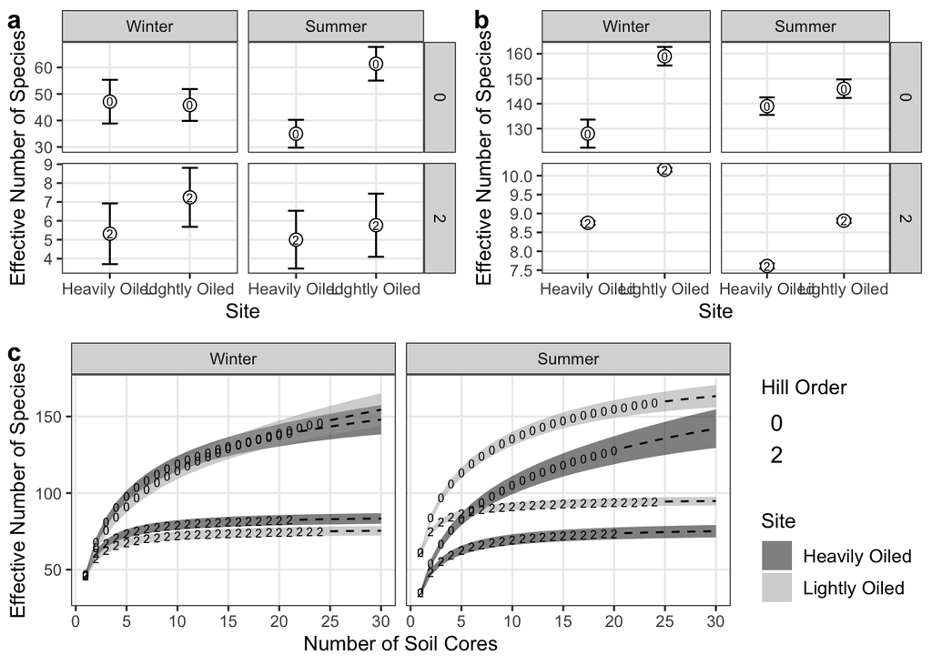

```r
top <- plot_grid(avg.abund.plot + theme(legend.position = "none"), abund.plot + theme(legend.position = "none"), labels = c("a", "b"))
plot_grid(top, inc.plot  + theme(legend.position = "right"), nrow = 2, labels = c('','c'))
```

```r
ggsave("../../../../results/images/manuscript/S2_MGF_final/S2_MGF_Fig2_v2.png", width = 10, height = 8, units = "in")
```

### Calculate min samples needed

For each site and time point, how many samples are needed to be the same, statistically, as when alpha diversity is calculated from all available samples.

```r
voi.hill <- subset(voi.inext.all, method=="observed")

#split data frame into list
voi.inext.list <- split.data.frame(voi.inext.all, voi.inext.all$group)

minsamp.list.0 <- list()
#minsamp.list.1 <- list()
minsamp.list.2 <- list()

voi.hill.0 <- subset(voi.hill, order==0)
#voi.hill.1 <- subset(voi.hill, order==1)
voi.hill.2 <- subset(voi.hill, order==2)

for(i in 1:nrow(voi.hill.0)){

  minsamp.list.0[[i]] <- voi.inext.list[[voi.hill.0$group[i]]] %>%
    as.data.frame(value = names(voi.inext.list[[voi.hill.0$group[i]]])) %>%
    filter(order==0 & qD.UCL < voi.hill.0[i]$qD.LCL) %>%
    select(t, order, group) %>%
    slice(n())
}

# for(i in 1:nrow(voi.hill.0)){
#
#   minsamp.list.1[[i]] <- voi.inext.list[[voi.hill.1$group[i]]] %>%
#     as.data.frame(value = names(voi.inext.list[[voi.hill.1$group[i]]])) %>%
#     filter(order==1 & qD.UCL < voi.hill.1[i]$qD.LCL) %>%
#     select(t, order, group) %>%
#     slice(n())
# }

for(i in 1:nrow(voi.hill.0)){
 minsamp.list.2[[i]] <- voi.inext.list[[voi.hill.2$group[i]]] %>%
    as.data.frame(value = names(voi.inext.list[[voi.hill.2$group[i]]])) %>%
    filter(order==2 & qD.UCL < voi.hill.2[i]$qD.LCL) %>%
    select(t, order, group) %>%
    slice(n())
}

#lists of threshold.  Remember that you need to add one to this because the code above asked to return the samples that had lower CI values
A <- rbindlist(minsamp.list.0)
#B <- rbindlist(minsamp.list.1)
C <- rbindlist(minsamp.list.2)

#make into pretty table
voi.hill.table <- voi.hill %>%
  select(site,season, order,qD,qD.LCL, qD.UCL,t ) %>%
  arrange(order)


voi.hill.table$min.samples <- NA
voi.hill.table$min.samples[voi.hill.table$order==0] <- A$t +1
#voi.hill.table$min.samples[voi.hill.table$order==1] <- B$t + 1
voi.hill.table$min.samples[voi.hill.table$order==2] <- C$t + 1

names(voi.hill.table) <- c("Site", "Season", "q (Hill order)", "Effective Number of Species", "Lower CI", "Upper CI","N", "Min. Samples")

voi.hill.table$estimate_type <- "Observed"
voi.hill.table$filtered <- "no"

voi.hill.table.observed.NF <- voi.hill.table

#Extrapolated version

voi.hill <- subset(voi.inext.all, method=="extrapolated") %>%
  filter(t==30)

#split data frame into list
voi.inext.list <- split.data.frame(voi.inext.all, voi.inext.all$group)

minsamp.list.0 <- list()
#minsamp.list.1 <- list()
minsamp.list.2 <- list()

voi.hill.0 <- subset(voi.hill, order==0)
#voi.hill.1 <- subset(voi.hill, order==1)
voi.hill.2 <- subset(voi.hill, order==2)

for(i in 1:nrow(voi.hill.0)){

  minsamp.list.0[[i]] <- voi.inext.list[[voi.hill.0$group[i]]] %>%
    as.data.frame(value = names(voi.inext.list[[voi.hill.0$group[i]]])) %>%
    filter(order==0 & qD.UCL < voi.hill.0[i]$qD.LCL) %>%
    select(t, order, group) %>%
    slice(n())
}

# for(i in 1:nrow(voi.hill.0)){
#
#   minsamp.list.1[[i]] <- voi.inext.list[[voi.hill.1$group[i]]] %>%
#     as.data.frame(value = names(voi.inext.list[[voi.hill.1$group[i]]])) %>%
#     filter(order==1 & qD.UCL < voi.hill.1[i]$qD.LCL) %>%
#     select(t, order, group) %>%
#     slice(n())
# }

for(i in 1:nrow(voi.hill.0)){
 minsamp.list.2[[i]] <- voi.inext.list[[voi.hill.2$group[i]]] %>%
    as.data.frame(value = names(voi.inext.list[[voi.hill.2$group[i]]])) %>%
    filter(order==2 & qD.UCL < voi.hill.2[i]$qD.LCL) %>%
    select(t, order, group) %>%
    slice(n())
}

#lists of threshold.  Remember that you need to add one to this because the code above asked to return the samples that had lower CI values
A <- rbindlist(minsamp.list.0)
#B <- rbindlist(minsamp.list.1)
C <- rbindlist(minsamp.list.2)

#make into pretty table
voi.hill.table <- voi.hill %>%
  select(site,season, order,qD,qD.LCL, qD.UCL,t ) %>%
  arrange(order)


voi.hill.table$min.samples <- NA
voi.hill.table$min.samples[voi.hill.table$order==0] <- A$t + 1
#voi.hill.table$min.samples[voi.hill.table$order==1] <- B$t + 1
voi.hill.table$min.samples[voi.hill.table$order==2] <- C$t + 1

names(voi.hill.table) <- c("Site", "Season", "q (Hill order)", "Effective Number of Species", "Lower CI", "Upper CI","N", "Min. Samples")

voi.hill.table$estimate_type <- "Extrapolated"
voi.hill.table$filtered <- "no"

voi.hill.table.extrapolated.NF <- voi.hill.table
```

### Filtered version

Run the same as above, but with rare species filtered out to see if it makes a difference in the number of samples needed.

```r
#Run iNEXT abundance

# melt phyloseq data to data frame
mdf <- psmelt(fung.2season_with_outliers_filtered)

# compute taxa sum according to sample type
sampletype_abund <- dplyr::group_by(mdf, OTU, site,season) %>%
  dplyr::summarise(abundance = sum(Abundance))
df.taxasums <- sampletype_abund %>%
pivot_wider(names_from = c(site,season), names_sep = ".", values_from = c(abundance)) %>%
  as.data.frame()

df.taxasums1 <- df.taxasums[,-1]
rownames(df.taxasums1) <- df.taxasums[,1]

Sys.time()
```

```
## [1] "2020-12-03 14:53:48 CST"
```

```r
 voi.inext.df.abund <- iNEXT(x = df.taxasums1,
                       q = c(0,2),
                      datatype = "abundance",
                      se = TRUE,
                      conf = 0.95,
                      nboot = 100,
                      endpoint = 600000)
Sys.time()
```

```
## [1] "2020-12-03 14:53:57 CST"
```

```r
#Took about 30 seconds on macbook pro

#make into one list
voi.inext.all.abund <- rbindlist(voi.inext.df.abund$iNextEst)

#add names column
voi.inext.all.abund$group <- rep(names(voi.inext.df.abund$iNextEst), each = 80)
voi.inext.all.abund$site <- c(rep("Heavily Oiled", 160),
                        rep("Lightly Oiled", 160))

voi.inext.all.abund$season <- rep(c(rep("Summer", 80), rep("Winter", 80)), 2)

#adjust factors
voi.inext.all.abund$season <- factor(voi.inext.all.abund$season, levels = c("Winter", "Summer"))
voi.inext.all.abund$order <- factor(voi.inext.all.abund$order)

#plot

#Just 0 and 2
voi.inext.all.abund <- voi.inext.all.abund %>%
  filter(order %in% c(0,2), method=="observed")

abund.plot <- voi.inext.all.abund %>%
  ggplot(aes(x = site,
           y = qD,
           shape = factor(order))) +
  facet_wrap(~ season) +
  geom_errorbar(aes(ymax = qD.UCL,
                    ymin = qD.LCL),
                width = 0.2) +
  geom_point(inherit.aes = FALSE,
             aes(x = site,
                 y = qD),
              shape = 21,
              fill = "white",
              color = "black",
              size = 3,
             stroke = 0.5) +
  geom_point(size = 2) +
  theme_bw() +
  theme(panel.grid.minor = element_blank()) +
  labs(x = "Site",
     y = "Effective Number of Species",
     shape = "Hill Order") +
  scale_shape_manual(values = c(48,50)) +
  guides(shape = guide_legend(label = FALSE, override.aes = list(size = 4))) +
  facet_grid(cols = vars(season),
              rows = vars(order),
              scales = "free")

#Run iNEXT incidence

voi.list <- list(fung.2season.BJ.summer_with_outliers_filtered,
                 fung.2season.BJ.winter_with_outliers_filtered,
                 fung.2season.F.summer_with_outliers_filtered,
                 fung.2season.F.winter_with_outliers_filtered)

#make otu_table_list
voi.list.OT <- lapply(voi.list, function(x) {
  as.data.frame(otu_table(x))
  })

#add names
names(voi.list.OT) <- c("fung.2season.BJ.summer_with_outliers_filtered",
                        "fung.2season.BJ.winter_with_outliers_filtered",
                        "fung.2season.F.summer_with_outliers_filtered",
                        "fung.2season.F.winter_with_outliers_filtered")


voi.list.OT <- lapply(voi.list.OT, function(x){
  x[x>0] <- 1
  return(x)  #important to remember this line of code
})


Sys.time()
```

```
## [1] "2020-12-03 14:53:58 CST"
```

```r
voi.inext.df.inc <- iNEXT(x = voi.list.OT,
                      q = c(0,2),
                      datatype = "incidence_raw",
                      size = c(1,2,3,4,5,6,7,8,9,10,11,12,13,14,15,16,17,18,19,20,21,22,23,24,25,26,27,28,29,30),
                      se = TRUE,
                      conf = 0.95,
                      nboot = 1000)
Sys.time()
```

```
## [1] "2020-12-03 14:54:08 CST"
```

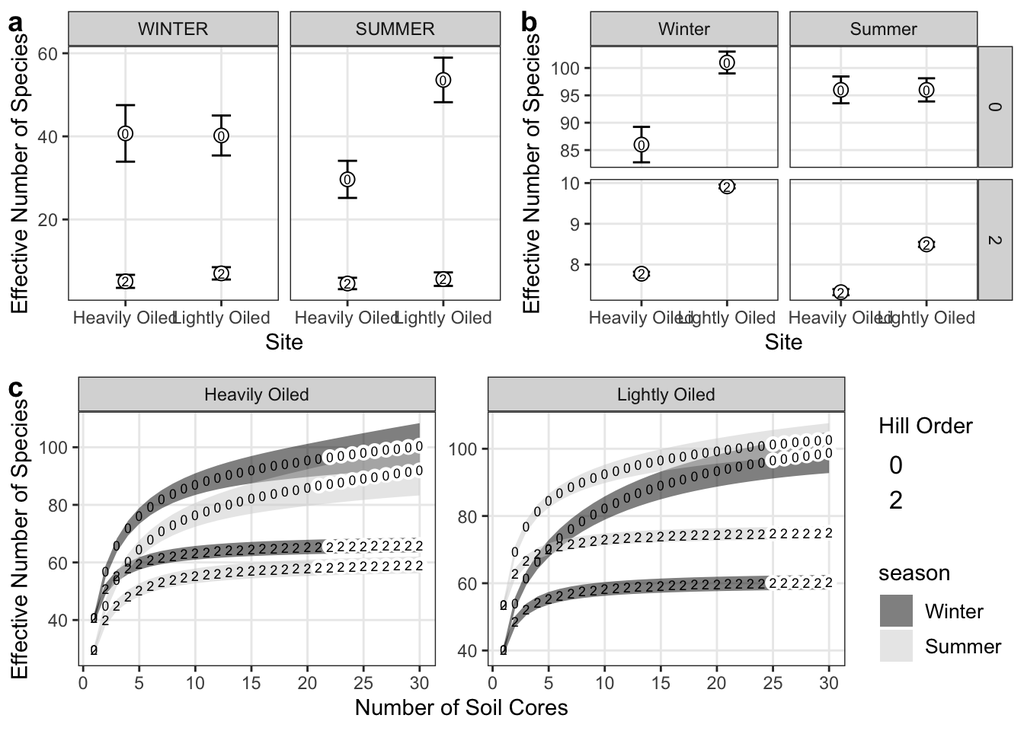

```r
#took about 30 seconds

#make into one list
voi.inext.all <- rbindlist(voi.inext.df.inc$iNextEst)

#add names column
voi.inext.all$group <- rep(names(voi.inext.df.inc$iNextEst), each = 60)
voi.inext.all$site <- c(rep("Heavily Oiled", 120),
                        rep("Lightly Oiled", 120))

voi.inext.all$season <- rep(c(rep("Summer", 60), rep("Winter", 60)), 2)

#adjust factors
voi.inext.all$season <- factor(voi.inext.all$season, levels = c("Winter", "Summer"))
voi.inext.all$order <- factor(voi.inext.all$order)

#plot

inc.plot <- voi.inext.all %>%
  ggplot(aes(x = t,
           y = qD,
           fill = season,
           shape = order)) +
  geom_ribbon(aes(ymax = qD.UCL,
                    ymin = qD.LCL),
               alpha = 0.5) +
  geom_point(inherit.aes = FALSE, data = voi.inext.all %>%
              filter(method=="extrapolated"),
             aes(x = t,
                 y = qD),
             shape = 21,
             fill = "white",
             color = "white",
             size = 3) +
  geom_point(size = 2, fill = "gray") +
  facet_wrap(~ site,
             scales = "free") +
  theme_bw() +
  theme(panel.grid.minor = element_blank()) +
  scale_x_continuous(breaks = seq(from = 0, to = 30, by = 5)) +
  labs(x = "Number of Soil Cores",
     y = "Effective Number of Species",
     shape = "Hill Order") +
  theme(legend.text = element_text(size = 10),
        legend.position = "bottom") +
  scale_shape_manual(values = c(48, 50)) +
  scale_fill_manual(values = c("black", "lightgray")) +
  guides(shape = guide_legend(label = FALSE, override.aes = list(size = 4)))

#ggsave("../../../../results/images/manuscript/S2_.png", width = 8.5, height = 7, units = "in")

#plot of observed Hill orders by abundance

p <- plot_richness(fung.2season_with_outliers_filtered)

#convert value to Hill numbers

p1 <- p$data

p1$value[which(p1$variable == "Observed")] <- p1$value[which(p1$variable == "Observed")]

p1$value[which(p1$variable == "Shannon")] <- exp(p1$value[which(p1$variable == "Shannon")])

p1$value[which(p1$variable == "Simpson")] <- 1/(1 - p1$value[which(p1$variable == "Simpson")])

p1$hill_order <- NA

p1$hill_order[which(p1$variable == "Observed")] <- 0
p1$hill_order[which(p1$variable == "Shannon")] <- 1
p1$hill_order[which(p1$variable == "Simpson")] <- 2

#rename levels for site
p1$site <- as.factor(p1$site)
levels(p1$site) <- plyr:::revalue(levels(p1$site), c("BJ" = "Heavily Oiled", "F" = "Lightly Oiled"))

p1$season <- factor(p1$season, levels = c("WINTER", "SUMMER"))

p1.summary <- summarySE(data = p1,
                        measurevar = "value",
                        groupvars = c("site", "season", "hill_order"))

#plot by site

avg_abund <- p1.summary %>%
  filter(hill_order %in% c(0,2)) %>%
  ggplot(aes(x = site,
           y = value,
           shape = factor(hill_order))) +
  facet_wrap(~ season) +
  geom_errorbar(aes(ymax = value + ci,
                    ymin = value-ci),
                width = 0.2) +
  geom_point(inherit.aes = FALSE,
             aes(x = site,
                 y = value),
              shape = 21,
              fill = "white",
              color = "black",
              size = 3) +
  geom_point(size = 2) +
  theme_bw() +
  theme(panel.grid.minor = element_blank()) +
  labs(x = "Site",
     y = "Effective Number of Species",
     shape = "Hill Order") +
  scale_shape_manual(values = c(48,50)) +
  guides(shape = guide_legend(label = FALSE, override.aes = list(size = 4)))


#plot all 3 plots

top <- plot_grid(avg_abund + theme(legend.position = "none"), abund.plot + theme(legend.position = "none"), labels = c("a", "b"))
plot_grid(top, inc.plot  + theme(legend.position = "right"), nrow = 2, labels = c('','c'))
```

```r
ggsave("../../../../results/images/manuscript/S2_MGF_final/S2_MGF_Fig2_filtered_v2.png", width = 10, height = 8, units = "in")


#calculate min samples for each group

voi.hill <- subset(voi.inext.all, method=="observed")

#split data frame into list
voi.inext.list <- split.data.frame(voi.inext.all, voi.inext.all$group)

minsamp.list.0 <- list()
#minsamp.list.1 <- list()
minsamp.list.2 <- list()

voi.hill.0 <- subset(voi.hill, order==0)
#voi.hill.1 <- subset(voi.hill, order==1)
voi.hill.2 <- subset(voi.hill, order==2)

for(i in 1:nrow(voi.hill.0)){

  minsamp.list.0[[i]] <- voi.inext.list[[voi.hill.0$group[i]]] %>%
    as.data.frame(value = names(voi.inext.list[[voi.hill.0$group[i]]])) %>%
    filter(order==0 & qD.UCL < voi.hill.0[i]$qD.LCL) %>%
    select(t, order, group) %>%
    slice(n())
}
#
# for(i in 1:nrow(voi.hill.0)){
#
#   minsamp.list.1[[i]] <- voi.inext.list[[voi.hill.1$group[i]]] %>%
#     as.data.frame(value = names(voi.inext.list[[voi.hill.1$group[i]]])) %>%
#     filter(order==1 & qD.UCL < voi.hill.1[i]$qD.LCL) %>%
#     select(t, order, group) %>%
#     slice(n())
# }

for(i in 1:nrow(voi.hill.0)){
 minsamp.list.2[[i]] <- voi.inext.list[[voi.hill.2$group[i]]] %>%
    as.data.frame(value = names(voi.inext.list[[voi.hill.2$group[i]]])) %>%
    filter(order==2 & qD.UCL < voi.hill.2[i]$qD.LCL) %>%
    select(t, order, group) %>%
    slice(n())
}

#lists of threshold.  Remember that you need to add one to this because the code above asked to return the samples that had lower CI values
A <- rbindlist(minsamp.list.0)
#B <- rbindlist(minsamp.list.1)
C <- rbindlist(minsamp.list.2)

#make into pretty table
voi.hill.table <- voi.hill %>%
  select(site,season, order,qD,qD.LCL, qD.UCL,t ) %>%
  arrange(order)


voi.hill.table$min.samples <- NA
voi.hill.table$min.samples[voi.hill.table$order==0] <- A$t +1
#voi.hill.table$min.samples[voi.hill.table$order==1] <- B$t + 1
voi.hill.table$min.samples[voi.hill.table$order==2] <- C$t + 1

names(voi.hill.table) <- c("Site", "Season", "q (Hill order)", "Effective Number of Species", "Lower CI", "Upper CI","N", "Min. Samples")

voi.hill.table
```

```
##             Site Season q (Hill order) Effective Number of Species Lower CI
## 1: Heavily Oiled Summer              0                      86.000   79.637
## 2: Heavily Oiled Winter              0                      96.000   90.044
## 3: Lightly Oiled Summer              0                     101.000   96.852
## 4: Lightly Oiled Winter              0                      96.000   90.746
## 5: Heavily Oiled Summer              2                      58.114   55.289
## 6: Heavily Oiled Winter              2                      65.451   62.935
## 7: Lightly Oiled Summer              2                      74.785   72.917
## 8: Lightly Oiled Winter              2                      60.052   57.890
##    Upper CI  N Min. Samples
## 1:   92.363 20           10
## 2:  101.956 21           10
## 3:  105.148 24           12
## 4:  101.254 24           14
## 5:   60.939 20            7
## 6:   67.968 21            6
## 7:   76.653 24            7
## 8:   62.213 24            6
```

```r
voi.hill.table$estimate_type <- "Observed"
voi.hill.table$filtered <- "yes"

voi.hill.table.observed.F <- voi.hill.table

#Extrapolated version

voi.hill <- subset(voi.inext.all, method=="extrapolated") %>%
  filter(t==30)

#split data frame into list
voi.inext.list <- split.data.frame(voi.inext.all, voi.inext.all$group)

minsamp.list.0 <- list()
#minsamp.list.1 <- list()
minsamp.list.2 <- list()

voi.hill.0 <- subset(voi.hill, order==0)
#voi.hill.1 <- subset(voi.hill, order==1)
voi.hill.2 <- subset(voi.hill, order==2)

for(i in 1:nrow(voi.hill.0)){

  minsamp.list.0[[i]] <- voi.inext.list[[voi.hill.0$group[i]]] %>%
    as.data.frame(value = names(voi.inext.list[[voi.hill.0$group[i]]])) %>%
    filter(order==0 & qD.UCL < voi.hill.0[i]$qD.LCL) %>%
    select(t, order, group) %>%
    slice(n())
}

# for(i in 1:nrow(voi.hill.0)){
#
#   minsamp.list.1[[i]] <- voi.inext.list[[voi.hill.1$group[i]]] %>%
#     as.data.frame(value = names(voi.inext.list[[voi.hill.1$group[i]]])) %>%
#     filter(order==1 & qD.UCL < voi.hill.1[i]$qD.LCL) %>%
#     select(t, order, group) %>%
#     slice(n())
# }

for(i in 1:nrow(voi.hill.0)){
 minsamp.list.2[[i]] <- voi.inext.list[[voi.hill.2$group[i]]] %>%
    as.data.frame(value = names(voi.inext.list[[voi.hill.2$group[i]]])) %>%
    filter(order==2 & qD.UCL < voi.hill.2[i]$qD.LCL) %>%
    select(t, order, group) %>%
    slice(n())
}

#lists of threshold.  Remember that you need to add one to this because the code above asked to return the samples that had lower CI values
A <- rbindlist(minsamp.list.0)
#B <- rbindlist(minsamp.list.1)
C <- rbindlist(minsamp.list.2)

#make into pretty table
voi.hill.table <- voi.hill %>%
  select(site,season, order,qD,qD.LCL, qD.UCL,t ) %>%
  arrange(order)


voi.hill.table$min.samples <- NA
voi.hill.table$min.samples[voi.hill.table$order==0] <- A$t + 1
#voi.hill.table$min.samples[voi.hill.table$order==1] <- B$t + 1
voi.hill.table$min.samples[voi.hill.table$order==2] <- C$t + 1

names(voi.hill.table) <- c("Site", "Season", "q (Hill order)", "Effective Number of Species", "Lower CI", "Upper CI","N", "Min. Samples")

voi.hill.table$estimate_type <- "Extrapolated"
voi.hill.table$filtered <- "yes"

voi.hill.table.extrapolated.F <- voi.hill.table

voi.hill.table <- rbind(voi.hill.table.observed.NF, voi.hill.table.observed.F, voi.hill.table.extrapolated.NF, voi.hill.table.extrapolated.F )

voi.hill.table
```

```
##              Site Season q (Hill order) Effective Number of Species Lower CI
##  1: Heavily Oiled Summer              0                     128.000  118.829
##  2: Heavily Oiled Winter              0                     139.000  131.501
##  3: Lightly Oiled Summer              0                     159.000  152.667
##  4: Lightly Oiled Winter              0                     146.000  136.871
##  5: Heavily Oiled Summer              2                      73.662   69.744
##  6: Heavily Oiled Winter              2                      82.465   79.051
##  7: Lightly Oiled Summer              2                      94.389   91.607
##  8: Lightly Oiled Winter              2                      74.997   71.936
##  9: Heavily Oiled Summer              0                      86.000   79.637
## 10: Heavily Oiled Winter              0                      96.000   90.044
## 11: Lightly Oiled Summer              0                     101.000   96.852
## 12: Lightly Oiled Winter              0                      96.000   90.746
## 13: Heavily Oiled Summer              2                      58.114   55.289
## 14: Heavily Oiled Winter              2                      65.451   62.935
```

[output cut: 53 more lines]

### Write stats to CSV

```r
write.csv(voi.hill.table, file = "../../../../results/images/manuscript/S2_MGF_final/S2_MGF_fig2_stats.csv", row.names = FALSE)
```